# Machine Learning

73-423 Forecasting for Economics and Business

## Outline

- What is ML?
- Trees
  - Bagging
  - Random Forests
  - Boosting
- Kernels

## Machine Learning for Forecasting

- Recently, area of quantitative prediction has experienced substantial development
- Often, results have been under the heading of **Machine Learning** (ML)
  - Use and development of **algorithms** for automated construction of **predictions** and **decisions** using **data**
- Precise characterization of what methods count as machine learning is contentious
  - By many standards, many principles and methods in this class could be characterized as ML
- Practically, “Machine Learning” is what Machine Learning researchers do
- An eclectic variety of methods, with most salient characteristic being that they “work”
- Performance usually defined in terms of statistical learning context
  - Given a data set $\mathcal{Z}^{\text{Train}}_{T_1}=(\mathcal{Y}^{\text{Train}}_{T_1},\mathcal{X}^{\text{Train}}_{T_1})$ produce predictions $\widehat{f}$, by some method or another
  - Such that when faced with new data $\mathcal{Z}^{\text{Test}}_{T_2}=(\mathcal{Y}^{\text{Test}}_{T_2},\mathcal{X}^{\text{Test}}_{T_2})$, predictions are accurate, in following sense:
    - For loss function $\ell:\ \mathbf{Y}\times\mathbf{Y}\to\mathbb{R}^{+}$, average loss over *test set* $\frac{1}{T_2}\sum_{t=1}^{T_2}\ell(y_{t},\widehat{f}(X_t))$ is small
- In forecasting case, $X_t$ contains past outcomes $\mathcal{Y}_{T-1}$ and observations are ordered in time
  - In general, observations may be unordered: customers, products, files, etc

## Characteristics of Machine Learning Methods

- Focused on prediction error
  - Do not restrict attention to rules that are simple or interpretable or produce complete models of data and environment
- Algorithmic
  - Procedures are automated, not using human input to adjust or evaluate predictions
  - Predictions may not even be expressed as functions you can write down, and can instead be produced by any series of steps that gives a number
- Nonlinear or nonparametric
  - Prediction rules as described need not be written as linear functions, or even describable using a finite set of known nonlinear forms
- High dimensional
  - Set of predictors used can be extremely large, including unconventional types of data like text, audio, or images

## Machine Learning Approaches

- Befitting a topic for which there is an entire department at CMU, coverage will be selective and shallow
  - A handful of popular methods, with limited discussion of theory or principles
- Today: “last generation” machine learning, roughly defined as “what you find in Hastie, Tibshirani, and Friedman (2009)”
- Some methods we have already discussed: e.g. regularized (structural) risk minimization
  - Lasso and other penalized approaches permit using many predictors
  - Cross validation is key tool for ensuring regularization chosen leads to low risk predictions
- Regularized versions of linear or logistic regression allow many predictors, but still impose linearity
  - Performance is okay, but usually can do much better with nonlinear methods
- Simple, easy to use, and extremely effective nonlinear methods are based on **trees**
  - Simplest possible nonlinear functions, used as building block in **boosting** and **bagging** for effective procedures
- Will also briefly discuss **reproducing kernel** methods
  - Nonlinear approach posessing beautiful and elegant theory: Performance usually “just okay”, but often better than simple linear methods
- Next class: Neural Networks and Deep Learning
  - Dominant approach in last 9 years, notable for success with new **types** of data

## Trees

- Suppose we have data $(y_t,X_t)$ in $\mathbb{R}\times\mathbb{R}^{N}$ or $\{0,1\}\times\mathbb{R}^{N}$
  - Former case is called **regression**, latter is called **classification**
- A (decision) **tree** is a piecewise constant function, defined sequentially
  - Pick some predictor $i\in 1\ldots N$, split space in two regions, where $x_{i,t}$ is above or below a threshold $s_1$
  - Within each region $x_{i,t}<s_1$, $x_{i,t}\geq s_1$, pick another predictor in $1\ldots N$, and another threshold $s_2$, and split the region in two
  - Continue choosing and splitting regions in two until space is split into $J$ non-overlapping rectangular subregions $\{R_j\}_{j=1}^{J}$
- Once space is split up into subregions, for each region $j=1\ldots J$ prediction depends only on the region of $X_t$
  - Formally, $f(X_t)=\sum_{j=1}^{J}b_j 1\{X_t\in R_j\}$ for some constants $b_j$
  - For classification case, can let $b_j\in\{0,1\}$: either yes or no in that region
- Prediction is then a sequence of yes-no decisions, like a game of 20 questions
  - “Is it blue?”
  - If so, ask “Is it bigger than a breadbox?” If not, ask “Does it have hair?”
  - Keep on asking questions for some series of steps, and then finally make prediction based on sequence of questions

## Fitting Trees

- Trees are the functions $\mathcal{F}=\{f(X)=\sum_{j=1}^{J}b_j1\{X_t\in R_j\},\ \{R_j\}_{j=1}^{J} \text{ are rectangular partition of }\mathbb{R}^{N},\ b\in\mathbb{R}^{J}\}$
- Class is not linear because thresholds defining the region also a choice, not just the coefficients on them
- Given a class of functions like trees, could just do empirical risk minimization, but rarely done in practice
  - Finding the optimum is computationally (NP) hard: searching all combinations of orderings, thresholds, coefficients can take hours or days
  - Goal is test set prediction, not in sample prediction, so effort only worth it if predictions better
- Instead, trees usually fit by faster “greedy” algorithm: **recursive binary splitting**
  - For each predictor $x_{i,t}$ $i=1\ldots N$, pick a threshold $s$ to split into regions $R_1=\{X:\ X_i<s\}$, $R_2=\{X:\ X_i\geq s\}$ to minimize loss $\sum_{t: X_{t}\in R_1}(y_{t}-\widehat{y}_{R_1})^2+\sum_{t: X_{t}\in R_2}(y_{t}-\widehat{y}_{R_2})^2$ where $\widehat{y}_{R_1}$ is the mean of the outcome in $R_1$, $\widehat{y}_{R_2}$ is the mean of the outcome in $R_2$
  - Choose the split $i\in1\ldots N$ with the smallest loss to define the chosen region
  - Within each region split by same approach, and continue until a stopping criterion met, like max depth or min # of $X_t$ in final region
  - Prediction is sample mean within each final region
- Mean squared error criterion for split is for regression: for other losses, like classification, can use other choice
- Method is “greedy” because split used is best at each level, not best sequence of splits

## Regularization and Evaluation

- Recursive partitioning reduces the in-sample prediction error at every step
- Although not finding the absolute minimum, method still has potential to overfit
- Can handle this with form of regularization called **pruning**
- Idea is that *once the tree is chosen by recursive partition*, can *remove* splits to find a smaller **subtree**
- Can choose which splits to remove using an information criterion
- If $|J|$ is number of total subregions $\{R_{j}\}_{j=1}^{|J|}$ of a subtree, criterion is $\sum_{j=1}^{|J|}\sum_{\{x_t\in R_j\}}(y_t-\widehat{y}_{R_j})^2+\alpha |J|$
  - Find the subtree with smallest criterion value, which trades off fit and complexity
  - Can choose $\alpha$ by, e.g., cross-validation
- Not the same as just doing regularized ERM over set of trees, since initial set chosen recursively
- With initial fit to low error then pruning, trees have decent out-of-sample performance
- Main advantage is interpretability: final rule is just sequence of yes-no steps

## Application: Mortgage Loan Approval

```r
library(rpart) # Fit Classification and Regression Trees (could also use "tree")
library(randomForest) # Fit Random Forests
#library(ranger) # Also fit random forests, but using faster method
library(xgboost) # Fit Gradient Boosting
library(kernlab) # Fit Reproducing Kernel Methods
#library(KRLS) #Fit least squares regression with kernels
library(caret) #Train and validate machine learning models
library(plyr) #Data manipulation
library(dplyr) # Data Manipulation


 #Load Data Set on Mortgage Loan Application Approvals
library(foreign) # Load data sets in Stata format
#Data on loan applications: see http://fmwww.bc.edu/ec-p/data/wooldridge/loanapp.des for descriptions
loanapps<-read.dta("http://fmwww.bc.edu/ec-p/data/wooldridge/loanapp.dta")

#Remove "action", which is more refined outcome variable, to predict binary yes-no loan approval
loanapp<-select(loanapps,-one_of("action","reject"))

#Split data into train and test sets
set.seed(998) #Ensure randomness is reproducible
# Take 75% random sample of approved and non-approved each into training data, 25% into test data
inTraining <- createDataPartition(loanapp$approve, p = .75, list = FALSE) #Function in "caret" library
training <- loanapp[ inTraining,]
testing  <- loanapp[-inTraining,]

# Fit classification tree to mortgage loan data to see approval
rpfit <- rpart(approve ~ ., data = training)


# Now try to simplify tree by pruning
# Use 10-fold cross-validation to fit complexity parameter, using caret library
fitControl <- trainControl(## 10-fold CV
                           method = "repeatedcv",
                           number = 10,
                           ## repeated ten times
                           repeats = 10)

#Cross-validate tuning parameters using RMSE
rpfit1  <- train(approve ~ ., data = training,
                 method = "rpart",
                 trControl = fitControl,
                 na.action = na.exclude)
```

- Use [data set](http://fmwww.bc.edu/ec-p/data/wooldridge/loanapp.des) of New York area applications for mortgage loans, containing 1989 applicants and 59 attributes
  - Contains variety of demographic, housing and credit-related characteristics
  - Split into training and test sets to compare models
- Use regression tree to predict conditional probability of loan approval given applicant status
  - Library **rpart** or **tree** can be used
- Results tell a story: first significant preditor is whether applicant meets the bank’s credit guidelines
  - If not, moved into split with low probability of approval
- Among those who do meet guidelines, next predictor is whether they qualify for private mortgage insurance
- Sequence of additional characteristics adjusts probability up or down
- Can prune tree to simplify model: use **caret** library, unified R interface for training, tuning, testing ML models
  - 10 fold CV selects $\alpha=$ 0.0333164 with RMSE 0.2533201
- Pruned tree reduced to just guidelines and private mortgage insurance as predictors

## Decision Tree for Mortgage Approval, Before and After Pruning

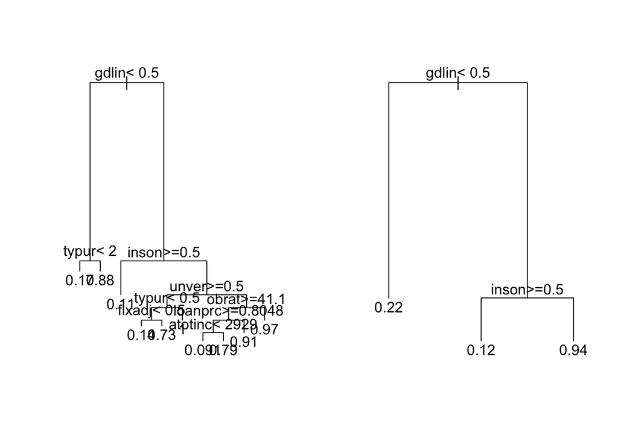

```r
#Plot sequence of partitions and outcomes
par(mfrow = c(1,2), xpd = NA) # otherwise on some devices the text is clipped
plot(rpfit)
text(rpfit, use.n = FALSE,digits=2)

#Plot pruned tree using CV-selected optimal tuning parameter
plot(rpfit1$finalModel)
text(rpfit1$finalModel, use.n = FALSE,digits=2)
```

## Model Combination

- Trees make nonlinear predictions over moderately large number of predictors by splitting space into big rectangles on which to make constant predictions
- In terms of quantitative precision, advantage over regression isn’t spectacular
- Reason trees are popular and effective method is that they work much better in model combination
- A combination of linear regressions is still a linear regression, but a combination of trees need not be a tree
  - Still piecewise constant, but regions don’t have to be rectangles
  - Can use model combination methods to combine multiple trees in a way that improves predictions
- Machine learning researchers have developed *algorithmic* model combination methods for these functions
  - Combine a very large number of simple models into one complex model with good performance

## Bagging

- Bagging, short for “bootstrap aggregation” is a way of performing regularization, by *averaging a model with itself*
- Idea is that model fit to one set of data can overfit, producing high variability
- If we had $2^{nd}$ data set, could fit model on that data and average prediction with that of the first model
  - Even though both overfit, they do so to different data, so shared component reflects systematic variation
- In practice, only have one data set, but can “pull yourself up by your own bootstraps” by **resampling** the data
- From original data set $\mathcal{Z}_{T}$ draw observations $(y_t,X_t)$ independently *with replacement* to create new data set $\mathcal{Z}_{b}$
  - Data set will on average have only about $\frac{2}{3}$ of original observations, with rest as duplicates
- Fit any model $\widehat{f}_b$ on data $\mathcal{Z}_{b}$, e.g., a decision tree by recursive partitions
- Then draw with replacement again to create another data set and fit the same model again to the new data set
- Repeat $B$ times, and use as the final model the average of all the models on different data sets $\mathcal{Z}_b$
  - $\widehat{f}^{\text{Bagged}}=\frac{1}{B}\sum_{b=1}^{B}\widehat{f}_b$
- Note each predictor fit to part of data set, so don’t gain quite as much for each from large samples
- But because errors produced this way nonsystematic, may get substantial out of sample improvement, especially if using a complex model prone to overfitting like a deep decision tree

## Random Forests

- Bagging can be applied to any procedure, but does well when fit model is a tree
- Large trees can incorporate info from many predictors, but variability can be high, which is helped by bagging
- Further, because average of trees doesn’t have to be a tree, bagging can also increase expressivity of model
- In practice, because data is shared between bags, tree fit within each tends to be pretty similar
- To increase expressivity of ensemble as a whole, force models to be different by only using a *random subset of features*
  - In each bag, sample $m<N$ random elements of $(x_{1,t},x_{2,t},\ldots,x_{N,t})$ and fit tree using only those features
  - Typically use $m\approx \frac{N}{3}$ for regression, $m\approx \sqrt{N}$ for classification
- Since “top” features may be removed, forced to find best prediction with other features instead
  - Each individual tree predicts less well, but with $B$ large, **combination** accounts for all features by including them in the average
- Final predictor is based on random collection of trees, and so is called a **Random Forest**
- Allows *nonlinear* predictions from very large number of predictors, while controlling overfitting by averaging
- In practice, for moderately sized data sets (100s-1000s of data points, features) random forests seem to give most accurate out of sample predictions of anything that runs “out-of-the-box”
  - Can do better by careful modeling with advanced methods, but worth your time to try random forests first

## Bagging and Random Forests on Time Series Data

- Resampling methods like bagging and random forests handle overfitting to in-sample data by removing random subsets of it and replacing with duplicate samples to produce method that does well on samples not in training data
- With time series data, feature set $X_t$ often contains past values of $y$
  - Removing subsets of $y_t$ would delete features used in prediction, making it not possible to fit
  - Solve this issue by resampling $(y_t,X_t)$ **pairs**, with needed lags of $y_t$ included in $X_t$
- Idea that random subsets of in-sample data are good proxies for out-of-sample relies on **stationarity**
  - If data has trend, or periods which differ substantially, precisely which sample is used makes a difference
  - More importantly, **test set** in forecasting problem is the future, which if nonstationary need not be like the past
- For this reason, methods should be applied to stationary series, with differencing or detrending as needed
- Other issue: samples removed may be correlated with remaining samples, so can still “overfit” to them even if not seen
  - E.g., lagged features may still be kept as predictors, even if not as outcomes
- Can alleviate this problem by resampling random consecutive **blocks** of observations, and fitting within blocks
  - If series is **weak dependent** and blocks reasonably large, get better approximation to truly out of sample data

## Exercise: Try it yourself

- Run and compare random forests to linear methods for predicting GDP growth in a [Kaggle notebook](https://www.kaggle.com/davidchilders/gdp-forecasting-with-machine-learning)

## Boosting

- An alternative method for aggregating models, also often used with trees, is **boosting**
- Bagging is designed for taking big complicated models prone to overfitting and stabilizing them by averaging
- Boosting takes many small models with weak in-sample fit and combines to produce a more accurate model
- Idea is to improve model sequentially by adjusting slightly in the direction of each new predictor
  - By an amount $\lambda$, called “learning rate”, often small, e.g., 0.01 or 0.001 each step
- Start with $\widehat{f}=0$, $\mathcal{R}_{T}=\mathcal{Y}_{T}$, and for steps $b=1\ldots B$
  - 1. Starting with data $(\mathcal{R}_{T},\mathcal{X}_{T})$ fit a decision tree $\widehat{f}^{b}$ by recursive partitioning with small number $d$ (eg 1, 2, etc) of maximum splits
  - 2. Update $\widehat{f}(.)=\widehat{f}(.)+\lambda\widehat{f}^{b}(.)$
  - 3. Obtain new **residuals** $r_t=r_t-\lambda\widehat{f}^{b}$ for all $r_t\in\mathcal{R}_{T}$
- Final predictor $\widehat{f}(.)=\sum_{b=1}^{B}\lambda\widehat{f}^{b}(.)$ ensures good fit because each subsequent $\widehat{f}^{b}$ accounts for weaknesses of last
- Because updates are slowed down by $\lambda$, avoid large oscillations and strong overfitting to noise
- Model complexity increases in $B$: should be $>>\lambda$ to get good in sample fit: use cross-validation for out-of-sample fit
- $d$ determines degree of interaction between variables
  - $d=1$ (“decision stump”) case fits additive model. Use $d=2,\ 3$ to get 2, 3-way interactions: can help to use 3-7

## Gradient Boosting

- Boosting as described above attempts to minimize mean squared error loss using sum of trees
- It is special case of method for general loss functions and more general predictors in each step, **gradient boosting**
- Start with $\widehat{f}=0$ $\mathcal{R}_{T}=\mathcal{Y}_{T}$, and for steps $b=1\ldots B$
  - 1. Starting with data $(\mathcal{R}_{T},\mathcal{X}_{T})$ fit a predictor $\widehat{f}^{b}$ which may be a tree or other small model
  - 2. (Optional): Update learning rate $\widehat{\gamma}=\underset{\gamma}{\arg\min}\sum_{t=1}^{T}\ell(y_t,\widehat{f}(.)+\gamma\widehat{f}^{b}(.))$
  - 3. Update model $\widehat{f}(.)=\widehat{f}(.)+\widehat{\gamma}\widehat{f}^{b}(.)$
  - 4. Obtain new **pseudo-residuals** $r_t=-\frac{\partial \ell(y_{t},\widehat{f}(x_t))}{\partial \widehat{f}(x_t)}$ for all $r_t\in\mathcal{R}_{T}$
- Each boosting step can be seen as moving in direction of best marginal improvement to prediction
  - Optimizing rate allows data to determine speed
- Allows boosting to be applied to classification problems and other cases where we use non-MSE loss
- Fast implementation in **xgboost** library has made method popular, and like random forests, is a good default choice
  - Maybe better overall performance, based on winning many forecasting competitions

## Feature Maps and Engineering

- Methods based on iterating a sequence of steps or random combinations work well in practice
- But hard to analyze from perspective of principles we have seen, like ERM or Bayes
- Benefit of ML methods is producing highly flexible predictors with large set of covariates without overfitting
- Can we get these benefits by simply using a better predictor or model class in our known methods?
- Consider adding nonlinearities in a linear prediction class $\mathcal{F}_1=\{f(x)=x_t\beta,\ \beta\in\mathbb{R}\}$
  - Starting with $x_t\in \mathbb{R}$, to get a nonlinear predictor, add nonlinear functions of it like $x_t^2$
  - This adds flexibility, but still quite restrictive, so add more features, $x_t^3$, $x_t^4$,
  - Resulting class $\mathcal{F}_P=\{f(x)=\sum_{p=1}^{P}x^{p}_t\beta_p,\ \beta\in\mathbb{R}^{P}\}$ gets more and more flexible, but parameters and complexity grow without bound, even if we restrict $\Vert \beta\Vert<C$, and even worse if $x_t\in\mathbb{R}^{N}$
  - Can think of transformation as defining a **feature map** $\Phi(x_t)=(x_t,x_t^2,\ldots)$ to space of predictors
- ML methods’ purpose is basically to act like a good feature map
  - Can mimic their performance if you know what kinds of features make good predictions
  - ML people call this “feature engineering”: use subject matter knowledge to transform predictors

## Kernel Methods

- Kernel methods work by defining an *infinite* feature map: a **function** called a **kernel function** $K(.,.):\ \mathcal{X}\times\mathcal{X}\to \mathbb{R}$
  - For each data point $x_t$, feature map is the function $K(x_t,.):\ \mathcal{X}\to\mathbb{R}$
- This seems like it would lead to great flexibility, but be impossible to work with
- Would you need to compute infinite set of coefficients?
  - If we choose $K(.,.)$ to have certain properties, and restrict to an appropriately bounded set, no!
- Optimize $\widehat{\alpha}=\underset{\alpha\in\mathbb{R}^T}{\arg\min}\sum_{t=1}^{T}\ell(y_t,\sum_{t=1}^{T}\alpha_s K(x_s,x_t))$ over $\alpha$ such that $\sum_{s=1}^{T}\sum_{t=1}^{T}\alpha_s\alpha_tK(x_s,x_t)\leq C$
  - Predictor has 1 coefficient per data point, with size bounded by constraint, and can be computed by evaluating kernel function at data points
  - This can be shown to be equivalent to ERM over an infinite dimensional but bounded feature space
  - Often used with special loss for speed improvements: **Support Vector Machine** results in sparse $\alpha$
- Most useful thing is that since $K(.,.)$ is a function, $x_t$ can be *anything* and we can represent it by a finite set of numbers
  - Want to use a photograph, an MP3, a brain scan, or the text from a website to predict? There’s a kernel for that!
- Example: Radial Basis kernel $K(x_s,x_t)=\frac{1}{\sqrt{2\pi}\sigma}\exp(-\frac{1}{2\sigma^2} d(x_s,x_t)^2)$ for distance $d$ between two points
  - Prediction function is sum of “bumps” which take similar values in neighborhood of an example

```r
# Fit a Random Forest using randomForest package, accessed through caret train function
# Caret provides additional diagnostics, but since no CV used here, mostly just for comparability
# We fit regression even though outcome is binary because goal is eliciting probabilities

forestControl <- trainControl(method = "none") ## Use Default Parameters all the Way

rffit1  <- train(approve ~ ., data = training,
                 method = "rf",
                 trControl = forestControl,
                 na.action = na.exclude)

splitspertree<-rffit1$finalModel$mtry
numbertrees<-rffit1$finalModel$ntree
```

```r
## Commented out cross-validation because very slow, and don't want it to run every time I recompile
# # Use 10-fold cross-validation to fit parameters, using caret library
# xgbfitControl <- trainControl(## 10-fold CV
#                            method = "repeatedcv",
#                            number = 10,
#                            ## repeated ten times
#                            repeats = 10)
#
# #Fit tuning parameters by cross-validation
# xgbfit1  <- train(approve ~ ., data = training,
#                  method = "xgbTree",
#                  trControl = xgbfitControl,
#                  na.action = na.exclude)


# Set parameters: learning rate eta, # of splits max.depth, MSE loss and rmse evaluation,etc
# Set parameters to be hard-coded at value chosen by cross validation
cvparam <- list(max_depth = 1, eta = 0.3, gamma=0, colsample_bytree=0.8,
                min_child_weight=1, subsample=1, objective = "reg:squarederror", eval_metric = "rmse")

## Syntax to train xgboost directly

# Extract features from training and test data
trainfeat<-select(training,-one_of("approve"))
testfeat<-select(testing,-one_of("approve"))
#Transform data into format needed for xgboost command
dtrain <- xgb.DMatrix(as.matrix(trainfeat), label=training$approve)
dtest <- xgb.DMatrix(as.matrix(testfeat), label = testing$approve)
#Set training and test sets for evaluation
watchlist <- list(train = dtrain, eval = dtest)

# Fit gradient boosted trees using xgboost
boostrounds<-50
bst <- xgb.train(params=cvparam, data=dtrain,verbose=0,nrounds=boostrounds,watchlist=watchlist)
```

```r
#Fit a radial basis kernel regression using kernlab and KRLS, again fit through caret

kernControl <- trainControl(## 10-fold CV
                            method = "repeatedcv",
                            number = 10,
                            ## repeated ten times
                            repeats = 10) ## Use Default Parameters all the Way

#Fit Support Vector Regression to centered and scaled data, and cross-validate constraint C and radial basis width sigma
kernfit  <- train(approve ~ ., data = training,
                 method = "svmRadial",
                 preProc = c("center", "scale"),
                 metric = "RMSE",
                 trControl = kernControl,
                 na.action = na.exclude)
```

## Application: Mortgage Approval Prediction Again

- Apply random forest, boosted decision trees, and kernel method using radial basis function kernel to same data set
- Random forests by **randomForest** using default settings: trees of depth 7 combined over 500 resamples of data
- Boosting trees with mean squared error loss by **xgboost**, using 10-fold CV to pick options: 50 iterations of depth 1 with a learning rate of 0.3
- Kernel regression with support vector regression loss over normalized data fit by **kernlab** using 10-fold CV to pick $\sigma=$ 0.0146091 in kernel and bound $C=$ 0.5 on max norm of coefficients
- Performance in sample okay for all, but kernel method performs worse in test set
- Boosting wins overall, but just barely, after long CV fit to choose parameters
- Random forests, in contrast, do nearly as well using default settings, in seconds

```r
#Construct test set predictions and RMSE for each
rppreds<-predict(rpfit1$finalModel, newdata = testing) #Decision Tree
#Use approximate imputation for missing values in random forest prediction, rather than excluding
rfpreds<-predict(rffit1$finalModel, newdata = na.roughfix(testing)) #Random Forest
bstpreds<-predict(bst,newdata=as.matrix(testfeat)) #Tree Boosting
kernpreds<-predict(kernfit$finalModel, newdata = testfeat) #Kernel Support Vector Regression

#Squared errors
prederrors<-data.frame((rppreds-testing$approve)^2,(rfpreds-testing$approve)^2,
                       (bstpreds-testing$approve)^2,(kernpreds-testing$approve)^2)

MSEvec<-colMeans(prederrors,na.rm=TRUE) #Mean Squared Errors


TestRMSE<-sqrt(MSEvec) #Test Set Root Mean Squared Errors

#Compute Training Set RMSE
rprmse<-rpfit1$results$RMSE[1] #Take from CV fit
rfrmse<-sqrt(rffit1$finalModel$mse[numbertrees]) #Take from model fit at last random forest
bstrmse<-bst$evaluation_log$train_rmse[boostrounds] #Take from model fit at last boosting iteration
kernrmse<-kernfit$results$RMSE[2] #Take from CV fit

TrainRMSE<-c(rprmse,rfrmse,bstrmse,kernrmse)
resmat<-as.matrix(data.frame(TestRMSE,TrainRMSE))
fitresults<-data.frame(t(resmat))

colnames(fitresults)<-c("Tree","Random Forest", "Boosting","Kernel SVM")


library(knitr)
library(kableExtra)
kable(fitresults,
  caption="Prediction Performance of ML Methods") %>%
  kable_styling(bootstrap_options = "striped")
```

Prediction Performance of ML Methods

|  | Tree | Random Forest | Boosting | Kernel SVM |
| --- | --- | --- | --- | --- |
| TestRMSE | 0.2397885 | 0.2252832 | 0.2211216 | 0.4324194 |
| TrainRMSE | 0.2533201 | 0.2344840 | 0.2189350 | 0.2770203 |

## Conclusions

- Wide variety of machine learning methods have been developed for prediction
  - Work well with large sets of predictors and complicated nonlinearities while maintaining out of sample performance
- Tree based methods split space of predictors recursively into regions to produce simple chain of yes-no rules
- Improve variance and overfitting of large nonlinear models by combining within resampled subsets of data: **bagging**
  - Applied to trees, with predictors also random, get **random forests**
- Small simple models can be fit sequentially to compensate for individual weak performance to produce strong overall model: **boosting**
- Kernels allow complex nonlinearities and high dimensional data without too much overfitting, by feature mapping
- These and dozens of other methods designed for similar tasks can be fit and compared using `caret` library
  - Alternative libraries: `tidymodels` for tidyverse, `scikit learn` for Python

## References

- Trevor Hastie, Robert Tibshirani, and Jerome Friedman (2009) " [The Elements of Statistical Learning: Data Mining, Inference, and Prediction](https://web.stanford.edu/~hastie/Papers/ESLII.pdf)" 2nd ed. Springer.
  - Classic reference on applied machine learning
- Gareth James, Daniela Witten, Trevor Hastie, and Robert Tibshirani (2013) “[An Introduction to Statistical Learning with Applications in R](https://www.statlearning.com/)” Springer
  - Same basic topics as above, but simpler exposition and R code
  - Today’s notes mostly correspond to Chapter 8, on tree models